# Forecasting Demand for National Research Supercomputing

Australian Academy of Science | Australian HPC Demand to 2030  
[GitHub Repository: https://github.com/yusufkurniar01/aas-supercomputing-demand-forecasting.git](https://github.com/yusufkurniar01/aas-supercomputing-demand-forecasting.git)

Author

Yusuf Kurnia Romadhon

# 1 Introduction and Objectives

## 1.1 Project Background and Forecasting Problem

High-performance computing (HPC) supports research that requires substantial computing resources, including scientific simulations and large scale data analysis (Australian Academy of Science 2024). In Australia, the National Computational Infrastructure (NCI) and the Pawsey Supercomputing Research Centre operate the two national Tier 1 HPC facilities available to researchers (National Computational Infrastructure, n.d.-b; Pawsey Supercomputing Research Centre, n.d.-a).

This project was undertaken with the Australian Academy of Science to examine historical research computing demand and forecast national HPC demand through 2030. It uses publicly available records from NCI, Pawsey, and the National Computational Merit Allocation Scheme (NCMAS) to analyse requested and allocated computing resources. The results are intended to inform discussions about future national computing infrastructure and public investment (Australian Academy of Science 2026).

Forecasting demand is difficult because allocated computing resources do not necessarily represent what researchers need. Allocation schemes operate within available capacity, so researchers may receive less computing time than they request (National Computational Infrastructure 2014b, 2020b). Requested compute also has limitations, as researchers may restrict their applications based on expected availability or choose not to apply. The analysis therefore distinguishes requested compute, allocated compute and the gap between them, while recognising that underlying demand cannot be measured directly from these records (Australian Academy of Science 2026).

Historical comparisons are further affected by changes in computing systems, reporting practices and service-unit accounting. CPU and GPU resources are measured differently, while revisions to Field of Research (FoR) classifications affect comparisons across years (Australian Bureau of Statistics 2020). Given the limited annual observations, the analysis distinguishes directly reported values from estimates and converted measures when preparing the historical dataset and interpreting forecasts.

## 1.2 Project Objectives

The main objective is to forecast Australian national research computing demand through 2030 using available historical records, while documenting the limitations of the data and the assumptions required for comparison.

The project has five objectives:

1. **Construct a historical dataset** of HPC demand and allocation from publicly available NCI, Pawsey and NCMAS records, with documented sources and reporting limitations.
2. **Standardise historical measures** by examining changes in computing systems, resource units and reporting practices, and applying conversion methods where necessary.
3. **Analyse demand and allocation patterns**, including requested and allocated resources, the gap between them, CPU and GPU demand, and FoR allocation composition.
4. **Develop and evaluate forecasting models** using the available annual observations, comparing forecast accuracy, model assumptions and sensitivity to recent data.
5. **Develop demand scenarios through 2030** and examine how different growth assumptions, historical FoR allocation patterns and illustrative allocation levels affect the results.

These objectives are consistent with the data analysis, forecasting and scenario development requirements in the internship brief (Australian Academy of Science 2026).

# 2 Data Sources and Preparation

## 2.1 Data Sources and Coverage

The analysis covers 13 financial years, from 2013/14 to 2025/26, represented by analytical years 2014-2026. Earlier data were assembled primarily from National Computational Infrastructure (NCI) annual reports and Pawsey Supercomputing Research Centre publications (National Computational Infrastructure 2014a, 2015, 2016, 2017, 2018, 2019, 2020a; Pawsey Supercomputing Research Centre 2017). More recent data were drawn from National Computational Merit Allocation Scheme (NCMAS) outcomes (National Computational Merit Allocation Scheme 2021, 2022, 2023, 2024, 2025, 2026).

The sources provide different levels of detail. Earlier publications mainly contain annual or facility-level summaries, while more recent NCMAS outcomes include project-level allocations, computing resources and research fields (National Computational Merit Allocation Scheme 2021, 2024, 2026). Different documents sometimes supplied requested compute, allocations and FoR information for the same year. Historical applicant guidance was also reviewed to understand changes in allocation rules and resource definitions (National Computational Infrastructure 2014b, 2020b, 2022, 2023, 2025).

Table 1: Main data sources and their analytical roles.

| Source | Information extracted | Use in analysis |
| --- | --- | --- |
| NCI annual reports | Historical allocations, computing systems and reported resources | Historical series construction |
| Pawsey publications | Allocation information, computing systems and resource usage | Supplementary facility evidence and cross-checks |
| NCMAS outcomes | Requested and allocated resources, projects and research fields | Demand, allocation and FoR analysis |
| Supporting publications | Accounting rules, resource descriptions and contextual indicators | Conversion assumptions and interpretation |

Research funding, workforce and research activity indicators were considered as potential predictors but were not included in the final models because sufficiently consistent annual series were unavailable.

## 2.2 Data Integration, Standardisation and Provenance

Information from NCI, Pawsey and NCMAS publications was organised into two datasets: an annual demand and allocation summary, and a Field of Research (FoR) allocation composition dataset. Records were aligned by reporting year, computing system and resource type, with detailed observations checked against published annual totals where available.

Financial years were assigned to their ending year. For example, 2013/14 was recorded as 2014. Computing system names, resource identifiers and research field labels were standardised to support comparisons across reporting periods. CPU, GPU and aggregate computing resources were identified separately, and differences in reporting scope were recorded before aggregation.

Original values, measurement units and source references were retained alongside standardised fields. Each observation was identified as directly reported, calculated from source information or estimated using documented assumptions. Missing resource breakdowns were not treated as observed values.

## 2.3 Variable Definitions and Measurement Units

The main annual variables are requested compute and allocated compute. Where both measures are available on a comparable basis, the request-to-allocation ratio is calculated as $R_t = D_t/A_t$, where $D_t$ represents requested compute and $A_t$ represents allocated compute in year $t$.

The corresponding fulfilment rate is $A_t/D_t$, and the request–allocation gap is $D_t - A_t$. All three indicators are calculated only when the values have compatible units and reporting scope (Australian Academy of Science 2026).

Historical records use different measurement units, including service units (SU), kilo service units (kSU), million compute hours, CPU core-hours and GPU-hours. Service units are accounting measures that depend on the computing system and resource type. Consequently, values expressed in kSU are not necessarily computationally equivalent across facilities.

CPU core-hours and GPU-hours were treated as separate measures.

## 2.4 Compute Resource Conversion

Historical service-unit values were converted using accounting factors specific to each computing system and resource type (National Computational Infrastructure, n.d.-b; Pawsey Supercomputing Research Centre, n.d.-a). Original values were retained, and conversions based on assumptions were identified separately from directly reported measures.

### 2.4.1 Conversion Formulas

Service units were converted to kilo service units using $\text{SU} = \text{kSU} \times 1{,}000$.

For CPU resources reported in kSU, core hours were calculated as $\text{CPU core-hours} = (\text{CPU kSU} \times 1{,}000)/(\text{SU per CPU core-hour})$. Similarly, GPU-hours were calculated as $\text{GPU-hours} = (\text{GPU kSU} \times 1{,}000)/(\text{SU per GPU-hours})$.

The denominators are system and resource specific accounting factors and were not assumed to remain constant across systems or reporting periods. Values already reported in CPU core-hours or GPU-hours were retained without conversion. Values reported in millions of hours were multiplied by 1,000,000 after confirming the original resource definition.

### 2.4.2 System Specific Conversion Rules

Table 2: Main compute-resource conversion rules recorded in the year-by-year conversion worksheet.

| System or resource | Reporting period | SU per resource-hour | Treatment |
| --- | --- | --- | --- |
| Raijin CPU and Magnus CPU | Selected historical years from 2013/14 | 1 | Historical baseline; assumptions apply to some records |
| Gadi CPU | 2020/21–2025/26 | 2 | System-specific accounting factor |
| Setonix CPU | 2021/22–2025/26 | 1 | System-specific accounting factor |
| Setonix GPU | 2021/22–2025/26 | 128 | GPU accounting factor |
| Setonix Q | 2025/26 | 256 | GH200 GPU-hour conversion |
| Previously reported million core-hours | Selected historical years | Not applicable | Multiply by 1,000,000 |

The factors were compiled from system-specific documentation and the project’s recorded conversion assumptions (National Computational Infrastructure, n.d.-a, 2025; Pawsey Supercomputing Research Centre, n.d.-c, n.d.-b). They were applied to the corresponding system and reporting period, rather than indiscriminately to aggregate kSU values without a resource breakdown.

For the earlier years, a factor of 1 SU per CPU core hour was used as a baseline assumption where a more specific accounting factor was unavailable. For some 2019/20 records, the original technical conversion used a documented working assumption of 100% Gadi CPU equivalent at 2 SU per CPU core hour because a reliable CPU/GPU split was unavailable. This assumption should not be interpreted as a directly observed resource breakdown.

Historical Fornax GPU records could not be converted reliably using the available information. These observations were retained with their original units rather than assigned an unsupported conversion factor.

### 2.4.3 Conversion Validation and Limitations

Converted values were checked against original units, system level records and published annual totals where comparable data were available. Aggregate service unit values were converted into CPU core-hours or GPU-hours only when resource breakdowns and accounting factors were available, or when a documented assumption was used.

Missing GPU observations were not treated as zero demand. Conversion assumptions and estimated values were retained in the technical documentation, together with the year by year conversion worksheet and validation code.

## 2.5 Field of Research Classification Alignment

The FoR data were standardised in two stages to support comparisons across 2014-2026.

The first stage addressed differences between the FoR 2008-based reporting period (2014-2020) and the FoR 2020 based period (2021-2026) (Australian Bureau of Statistics 2020). Selected historical fields were combined into broader reporting categories through `for_analysis_group`, while the existing standardised categories were retained for the later period.

The second stage established nine analytical groups for longitudinal comparison through `for_visual_group`. These groups were informed by the broader research field categories used in NCI and Pawsey annual reporting. Related categories were combined where reporting detail differed across years, rather than assuming that the two FoR classification systems were directly equivalent.

Original field labels were cleaned by removing numerical prefixes, standardising capitalisation, replacing “&” with and, and removing extra spaces. The cleaned labels were then assigned to the nine groups using explicit matching rules.

Table 3 summarises the analytical grouping applied to the reported research fields.

Table 3: Analytical FoR grouping rules used for longitudinal comparison across 2014–2026.

| Analytical group | Reported fields included |
| --- | --- |
| Physical Sciences | Physical sciences and radioastronomy |
| Chemical Sciences | Chemical sciences |
| Earth & Environmental Sciences | Earth sciences, environmental sciences and geosciences |
| Engineering & Technology | Engineering and technology |
| Biological & Agricultural Sciences | Biological, agricultural, veterinary and food sciences |
| Medical & Health Sciences | Medical, health, biomedical and clinical sciences |
| Mathematics & Computing | Mathematical sciences, computing and information sciences |
| Social Sciences, Humanities & Built Environment | Psychology, economics, humanities, social sciences, design and built environment |
| Unclassified & Operational | Other, unreported, unclassified and Pawsey operational categories |

The groupings were developed for analytical consistency and do not represent official one to one conversions between ANZSRC 2008 and ANZSRC 2020. Original research field labels and allocation values were preserved.

The 2016/17 Pawsey records contain facility-wide usage information, which differs in scope from the NCMAS allocation data used for other years (Pawsey Supercomputing Research Centre 2017). This difference was retained when preparing the historical FoR dataset and is considered when comparing allocation shares across years.

Validation checks confirmed that all 133 FoR records had the required classification and allocation information, all reported fields were assigned to one of the nine analytical groups, and annual allocation shares summed to 100%.

The complete mapping rules and validation code are available in the technical Quarto documentation.

# 3 Forecasting Methodology

## 3.1 Forecasting Framework

Overall HPC demand (kSU), CPU demand (core hours) and GPU demand (GPU-hours) were forecast separately because their measurement conventions and historical coverage differ. Field of Research (FoR) scenarios were developed from historical allocation shares because consistent field-level demand records were unavailable.

Given the limited annual observations, the analysis used naïve, drift, linear trend and log-linear trend models to compare different growth assumptions. Model selection considered forecast accuracy, interpretability and suitability for projections through 2030 (Hyndman and Athanasopoulos 2021).

## 3.2 Forecasting Models

Four methods were evaluated: naïve, drift, linear trend and log-linear trend (Hyndman and Athanasopoulos 2021). Naïve and drift served as benchmarks for assessing the trend models.

### 3.2.1 Naïve and Drift Benchmarks

The naïve method uses the latest observation as the forecast, $\hat{y}_{T+h} = y_T$, where $y_T$ is the last observed value and $h$ is the forecast horizon.

The drift method extends the average annual change between the first and last training observations: $\hat{y}_{T+h} = y_T + h(y_T-y_1)/(T-1)$, where $y_1$ is the first observation and $T$ is the number of training observations (Hyndman and Athanasopoulos 2021).

### 3.2.2 Linear Trend Model

The linear trend model assumes a constant absolute annual change in demand (Hyndman and Athanasopoulos 2021):

$$y_t = \beta_0 + \beta_1 t + \varepsilon_t$$

Here, $y_t$ is demand in year $t$, $\beta_0$ is the intercept, $\beta_1$ is the estimated annual change and $\varepsilon_t$ is the error term. For CPU demand measured in millions of core-hours, $\beta_1$ represents the estimated annual change in millions of core-hours.

The model extends the historical linear trend through 2030 without explicitly accounting for future changes in computing technology, allocation policies or research funding.

### 3.2.3 Log-Linear Trend Model

The log-linear model assumes a constant proportional growth rate (Hyndman and Athanasopoulos 2021):

$$\log(y_t) = \beta_0 + \beta_1 t + \varepsilon_t$$

The implied annual percentage growth rate is $g = (e^{\beta_1}-1)\times100\%$.

Unlike the linear model, the log-linear model allows the absolute annual increase to grow over time. It requires positive demand observations and assumes that historical proportional growth continues through the forecast period. Its projections were compared with the linear model to assess the effect of different growth assumptions.

## 3.3 Forecasting Targets and Historical Coverage

The forecasting models were applied separately to the available demand measures.

Table 4: Forecasting targets and historical coverage.

| Forecasting target | Historical period | Measurement unit | Main consideration |
| --- | --- | --- | --- |
| Overall HPC demand | 2014-2026 | kSU | Historical reporting and accounting comparability |
| CPU demand | 2014-2026 | Million CPU core-hours | System-specific conversion assumptions |
| GPU demand | 2022-2026 | Million GPU-hours | Shorter series and estimated resource-level values |

The HPC and CPU series contain 13 annual observations covering 2014-2026. GPU modelling was restricted to five observations from 2022–2026 because earlier GPU-hour estimates relied on less-supported conversion assumptions. The recent GPU series also includes derived values, limiting the reliability of model evaluation and forecasts.

All models were fitted separately for each demand measure. Forecasts were expressed in the corresponding units rather than combining CPU core-hours and GPU-hours.

## 3.4 Model Evaluation

### 3.4.1 Rolling-Origin Cross-Validation

Forecasting performance was assessed using expanding window, one step ahead rolling origin cross validation. This approach evaluates forecasts against observations that were not available when the models were fitted (Tashman 2000; Hyndman and Athanasopoulos 2021).

Under this approach, a model was fitted using the observations available up to a particular year and then used to predict the following year. The training window was expanded by one observation for each subsequent evaluation.

This approach preserves the chronological order of the data and avoids using future observations to estimate earlier forecasts.

For overall HPC and CPU demand, the initial training period covered 2014-2020. One step ahead forecasts were evaluated for 2021-2026, producing six forecast errors for each model.

For GPU demand, the initial training period covered 2022 - 2024, with forecasts evaluated for 2025 and 2026. This provided only two forecast errors, making GPU model comparisons less reliable than those for overall HPC and CPU demand. Because evaluation used one-step-ahead forecasts, the accuracy measures do not directly establish performance over the full four-year projection horizon.

### 3.4.2 Forecast Accuracy Measures

Forecast accuracy was assessed using Root Mean Squared Error (RMSE) and Mean Absolute Error (MAE) (Hyndman and Koehler 2006; Hyndman and Athanasopoulos 2021):

$$\text{RMSE} = \sqrt{\frac{1}{n}\sum_{t=1}^{n}(y_t-\hat{y}_t)^2},
\qquad
\text{MAE} = \frac{1}{n}\sum_{t=1}^{n}|y_t-\hat{y}_t|$$

where $y_t$ is the observed value, $\hat{y}_t$ is the forecast and $n$ is the number of evaluated forecasts.

Both measures use the same units as the forecasting target, with lower values indicating better accuracy. RMSE gives greater weight to larger errors, while MAE measures the average absolute error. Both were used because individual errors can strongly affect results over a short evaluation period.

Model accuracy was compared separately for HPC, CPU and GPU demand because their measurement units differ.

## 3.5 Model Selection and Sensitivity Analysis

Model selection considered predictive accuracy, interpretability and the assumptions required to extend historical trends through 2030.

A model with the lowest historical error was not automatically selected if its growth assumptions produced projections that were difficult to justify from the available evidence.

The linear and log-linear specifications were compared particularly closely because they represent different future growth patterns. Linear models assume a constant absolute annual increase, while log-linear models imply compounded proportional growth.

A sensitivity analysis was also conducted by fitting trend models with and without the 2026 observation. This examined how strongly the latest reported year influenced estimated growth and the resulting projections.

The comparison was intended to assess sensitivity to the historical sample rather than determine whether the 2026 observation represented a temporary or permanent change.

Forecast trajectories derived from different model specifications were treated as alternative assumptions, not formal statistical prediction intervals.

## 3.6 Field of Research Scenario Development

The FoR scenarios were developed separately from the HPC, CPU and GPU forecasting models because the available research-field data describe allocated resources rather than independently observed demand.

A top-down approach was used to distribute the selected overall HPC demand forecast across nine harmonised FoR groups. For research field $i$ and forecast year $t$, the indicative demand was calculated as $\hat{D}_{i,t} = \hat{D}_t \times s_i$, where $\hat{D}_t$ is the overall HPC demand forecast and $s_i$ is the assumed allocation share for field $i$.

Three historical periods were used to calculate alternative shares: recent (2021-2026), full period (2014-2026) and earlier (2014-2020). Within each period, allocation shares were averaged across available years, giving each year equal weight. Missing group-year observations were not treated as zero, and the resulting average shares were normalised to sum to 100%.

The scenarios show how different historical allocation patterns affect the indicative distribution of projected HPC demand. They are not independently validated forecasts of future demand by research field.

## 3.7 Forecast Horizon and Interpretation

Forecasts were generated for 2027 - 2030 by fitting the selected models to the available historical observations. Alternative growth assumptions and models excluding 2026 were retained for sensitivity analysis.

The projections extend historical demand trends rather than estimate future infrastructure capacity requirements directly. They do not explicitly account for changes in research policy, computing technology or access to HPC resources. Historical accounting differences and the limited annual observations, particularly for GPU demand, also restrict forecast reliability.

An additional allocation sensitivity analysis compared the central 2030 HPC demand forecast with three illustrative allocation levels: the 2026 allocation, 25% above that level and 50% above it. For each scenario, the request–allocation gap and fulfilment rate were calculated. The analysis also estimated the allocation levels required to maintain the 2026 fulfilment rate and achieve 50% fulfilment in 2030. These comparisons were used for planning interpretation rather than forecasting future allocations or infrastructure capacity.

# 4 Results

## 4.1 Initial Analysis

Historical requests and allocations were examined for overall HPC, CPU and GPU resources. Field of Research (FoR) allocation shares were analysed separately. Differences in reporting and conversion methods were considered when interpreting the historical patterns.

### 4.1.1 Historical HPC Demand and Allocation

Figure 1 shows historical HPC requests and allocations from 2014 to 2026.

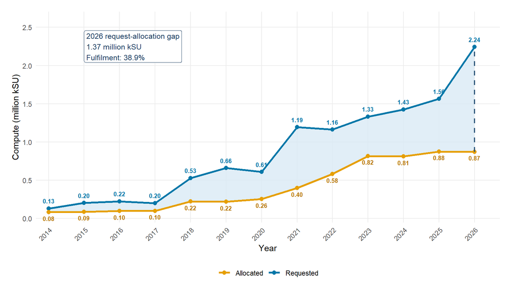

Figure 1: Historical HPC requests and allocations, 2014-2026.

Recorded requests increased from 131,356 kSU in 2014 to 2,242,817 kSU in 2026, while allocations increased from 83,505 to 872,288 kSU. Between 2023 and 2026, requests rose by approximately 68%, compared with 6% for allocations. The 2026 request–allocation gap reached 1.37 million kSU, with fulfilment falling from 56.0% in 2025 to 38.9% in 2026.

Requests rose by 43.3% between 2025 and 2026, based on the reconstructed 2025 value. Historical comparisons are affected by changes in computing systems and service unit accounting, particularly around the Raijin to Gadi and Magnus to Setonix transitions. The 2026 allocation total also excludes 12,000 kSU associated with Setonix Q. The request allocation gap does not account for research demand that was never submitted.

### 4.1.2 CPU Demand and Allocation

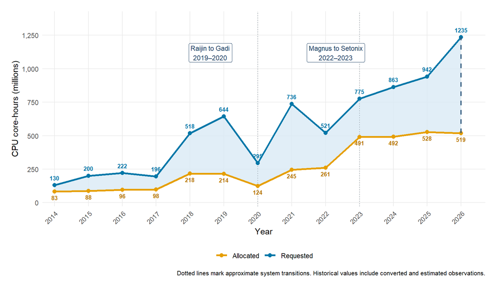

Figure 2: Historical CPU requests and allocations, 2014-2026.

Figure 2 presents the reconstructed CPU request and allocation series for 2014 to 2026. Estimated CPU requests reached approximately 1.24 billion core hours in 2026, compared with 519 million core hours allocated. Requests increased from 775 million core hours in 2023 to 1,235 million in 2026, while allocations remained close to 500 million core hours over those years.

The series also contains substantial fluctuations around 2019–2022, spanning the Raijin to Gadi and Magnus to Setonix transitions. Different accounting factors and incomplete CPU/GPU breakdowns complicate comparisons across these periods. In particular, some 2019/20 values use a Gadi CPU equivalent assumption rather than an observed resource split. These limitations affect the interpretation of individual annual changes and the reconstructed long-term trend.

### 4.1.3 GPU Demand and Allocation

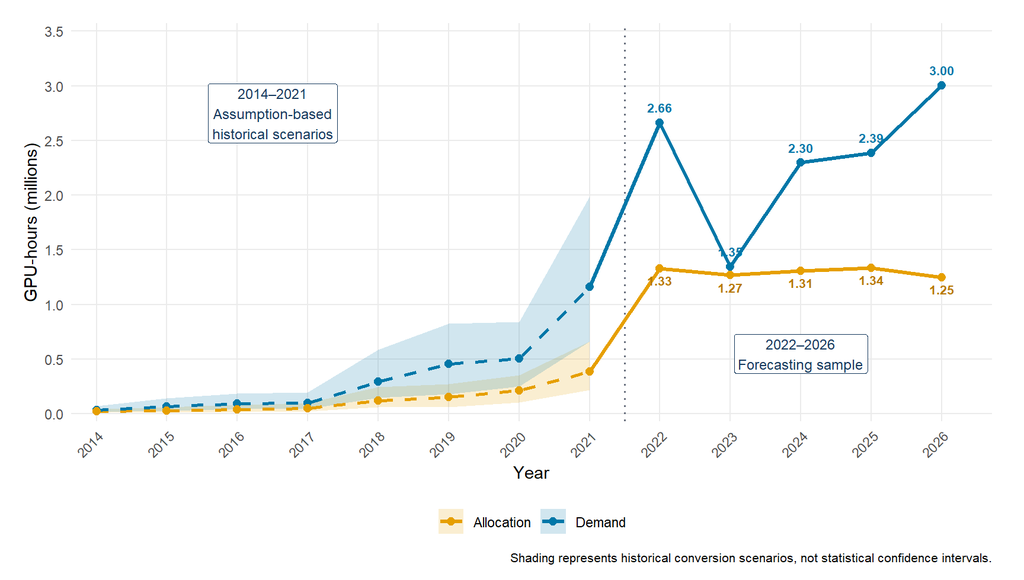

Figure 3: Historical GPU demand and allocation, 2014-2026.

Figure 3 distinguishes assumption based historical GPU estimates for 2014-2021 from the 2022-2026 series used for forecasting.

Earlier records did not consistently identify GPU-hours or provide sufficient information for system specific conversions. Alternative assumptions were therefore used to construct baseline and low high historical estimates. The shaded ranges in the figure represent differences between conversion assumptions, not statistical confidence intervals. These earlier estimates were excluded from model evaluation.

Estimated GPU requests fell from approximately 2.66 million GPU-hours in 2022 to 1.35 million in 2023, before increasing to 3.00 million in 2026. Estimated GPU allocations were approximately 1.25 million GPU-hours in 2026.

Official Setonix GPU requests increased by approximately 123% in service units between 2023 and 2026, but this increase cannot be interpreted directly as growth in GPU-hours. The five-year forecasting sample and reliance on converted observations limit the reliability of projections to 2030.

### 4.1.4 Field of Research Allocation Composition

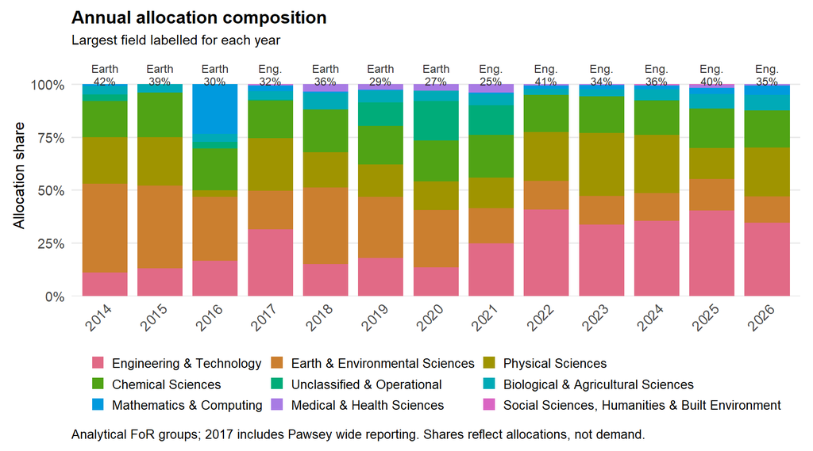

Figure 4: Annual HPC allocation shares by research field, 2014-2026.

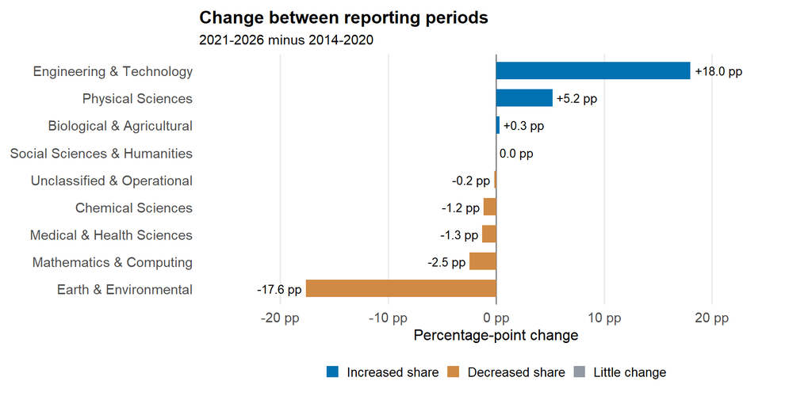

Figure 5: Change in average HPC allocation shares by research field, 2014-2020 versus 2021-2026.

Figure 4 and Figure 5 show annual HPC allocation shares across nine analytical Field of Research (FoR) groups and changes in average shares between 2014-2020 and 2021-2026.

Earth and Environmental Sciences was the largest group in most years during 2014–2020, accounting for 42% of allocations in 2014. Engineering and Technology was the largest group in 2017 and again from 2021 to 2026, representing 41% in 2022 and 35% in 2026.

Between the two periods, Engineering and Technology gained 18.0 percentage points in average annual allocation share, followed by Physical Sciences (+5.2 percentage points). Earth and Environmental Sciences declined by 17.6 percentage points, while Mathematics and Computing declined by 2.5 percentage points.

These comparisons are affected by the transition from FoR 2008 to FoR 2020 classifications and the inclusion of Pawsey wide reporting in 2016/17. The differences describe recorded allocation composition, not independently observed demand by research field. Section 4.4 uses these historical shares to construct alternative distributions of projected HPC demand.

## 4.2 Forecast Model Evaluation

The naïve, drift, linear trend and log-linear trend models were compared using one-year-ahead rolling-origin forecasts. HPC and CPU accuracy was evaluated over 2021-2026, with six forecasts per model. GPU accuracy was evaluated over 2025 - 2026, with two forecasts per model. Accuracy results are reported separately because the three demand measures use different units.

### 4.2.1 Overall HPC Demand

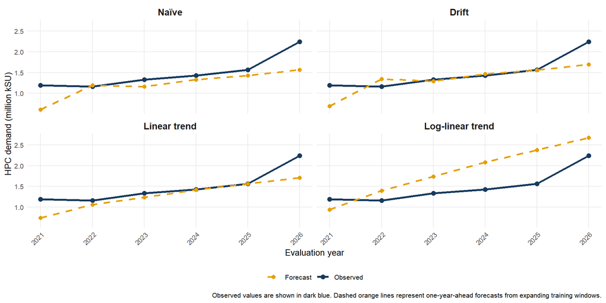

Figure 6: Observed HPC demand and one-year-ahead forecasts, 2021-2026

Table 5 summarises forecast accuracy over 2021-2026. The linear trend achieved the lowest RMSE (290,898 kSU) and MAE (198,295 kSU), outperforming both benchmark methods on these measures. The log-linear model had the highest RMSE (511,614 kSU) and MAE (466,991 kSU).

Table 5: Rolling-origin forecast accuracy for overall HPC demand, 2021-2026.

| Model | RMSE (kSU) | MAE (kSU) | RMSE rank |
| --- | --- | --- | --- |
| Linear trend | 290,898 | 198,295 | 1 |
| Drift | 314,588 | 221,778 | 2 |
| Naïve | 378,864 | 283,000 | 3 |
| Log-linear trend | 511,614 | 466,991 | 4 |

The linear trend was selected as the central HPC forecasting model based on its evaluation accuracy and constant absolute-growth assumption. Including 2026 increased the fitted annual trend from approximately 144,357 to 161,992 kSU (12.2%). A model excluding 2026 was therefore retained to assess sensitivity to the latest observation, while the log-linear model was retained to examine continued proportional growth.

These results are based on six one-year-ahead forecasts and do not establish accuracy through 2030. Section 4.3.1 compares the resulting projections.

### 4.2.2 CPU Demand

Figure 7 compares observed CPU demand with one-year-ahead forecasts over 2021-2026. The naïve and drift models produced relatively large errors around the decline in 2022. The linear trend forecasts were closer to observed demand during 2023-2025 but underestimated the increase in 2026. The log-linear model generally overestimated demand during 2022-2025, although its 2026 forecast was closer to the observed value.

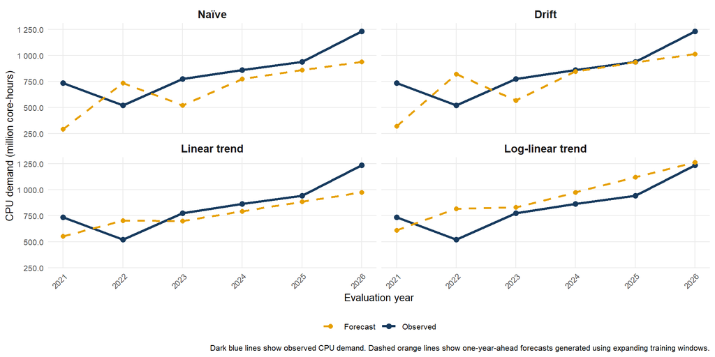

Figure 7: Observed CPU demand and one-year-ahead forecasts, 2021-2026.

Table 6 reports forecast accuracy across the six evaluation years. The linear trend achieved the lowest RMSE (157.72 million core hours), while the log-linear model achieved the lowest MAE (133.74 million core hours). Linear RMSE was approximately 1.5% lower than log-linear RMSE, whereas log-linear MAE was approximately 3.5% lower than linear MAE. Neither model performed best on both measures.

Table 6: Rolling-origin forecast accuracy for CPU demand, 2021-2026.

| Model | RMSE (million core-hours) | MAE (million core-hours) | RMSE rank |
| --- | --- | --- | --- |
| Linear trend | 157.72 | 138.65 | 1 |
| Log-linear trend | 160.18 | 133.74 | 2 |
| Drift | 242.61 | 193.69 | 3 |
| Naïve | 260.05 | 228.45 | 4 |

The linear trend was selected as the central CPU forecasting model because it achieved the lowest RMSE and assumes a constant absolute annual increase. The log-linear model was retained as an alternative because it achieved the lowest MAE and represents continued proportional growth.

Including 2026 increased the fitted linear trend from 72.41 million to 81.01 million CPU core-hours per year (11.9%). The model excluding 2026 was therefore retained to assess how the latest observation affects projections through 2030 (Section 4.3.2).

### 4.2.3 GPU Demand

Figure 8 compares observed GPU demand with one year ahead forecasts for 2025 and 2026. All four models underestimated demand in 2026, when estimated requests reached approximately 3.00 million GPU-hours. The naïve model forecast approximately 2.39 million GPU-hours, while the trend models also failed to anticipate the increase.

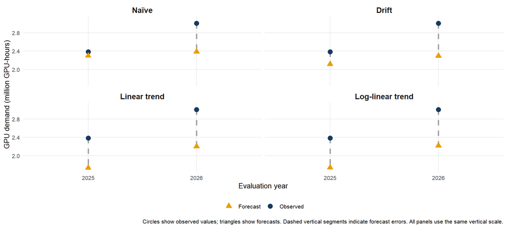

Figure 8: Observed GPU demand and one-year-ahead forecasts, 2025-2026.

Table 7 reports the results from the two evaluation years. The naïve model achieved the lowest RMSE (0.441 million GPU-hours) and MAE (0.353 million GPU-hours), followed by drift, log-linear trend and linear trend.

Table 7: Exploratory rolling-origin forecast accuracy for GPU demand, 2025-2026.

| Model | RMSE (million GPU-hours) | MAE (million GPU-hours) | RMSE rank |
| --- | --- | --- | --- |
| Naïve | 0.441 | 0.353 | 1 |
| Drift | 0.537 | 0.490 | 2 |
| Log-linear trend | 0.719 | 0.715 | 3 |
| Linear trend | 0.729 | 0.725 | 4 |

These rankings are based on only two forecast errors per model and a series containing converted and estimated observations. Although the naïve model achieved the lowest errors, this does not establish that it would outperform the trend models over a longer evaluation period or that GPU demand will remain constant.

The naïve model was retained as a benchmark alongside linear and log-linear projections under alternative growth assumptions. No central GPU forecasting model was selected. The projections in Section 4.3.3 are exploratory and were not used to distribute national HPC demand across research fields in Section 4.4.

### 4.2.4 Residual Diagnostics

Residual diagnostics were conducted on the linear trend models fitted to the full 2014-2026 HPC and CPU demand series, separately from the rolling origin accuracy evaluation. Residual ACF plots and Ljung–Box tests were used to examine autocorrelation, while normal Q–Q plots were used to assess departures from the normal-error assumption underlying the model-based prediction intervals. Figure 9 presents these results.

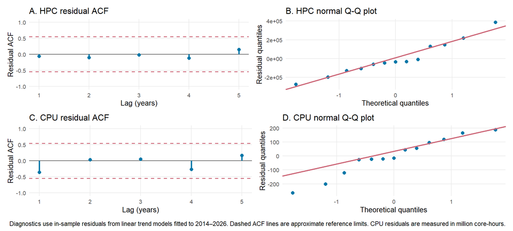

Figure 9: Residual diagnostics and Q-Q analysis for the selected HPC and CPU linear models.

None of the displayed residual autocorrelations exceeds the approximate ACF reference limits. HPC residual correlations are generally small, while CPU residuals show negative correlations at lags 1 and 4. Table 8 reports the Ljung–Box tests using three lags.

Table 8: Ljung–Box tests of residual autocorrelation for the selected linear trend models, using three lags.

| Demand measure | Ljung-Box statistic | Lag | Degrees of freedom | p-value |
| --- | --- | --- | --- | --- |
| Overall HPC | 0.271 | 3 | 3 | 0.965 |
| CPU | 2.092 | 3 | 3 | 0.554 |

The Ljung–Box tests did not reject the null hypothesis of no residual autocorrelation at three lags (HPC: $p = 0.965$; CPU: $p = 0.554$). However, the 13 annual observations provide limited power to detect residual dependence.

The HPC Q–Q plot shows departures from the normal reference line in the upper tail, while the CPU plot shows more noticeable departures in the lower tail. These findings do not invalidate the linear forecasts, but they limit confidence in the normal-error assumptions used to construct the prediction intervals in Section 4.3.

## 4.3 Demand Forecasts to 2030

### 4.3.1 Overall HPC Demand

The linear trend model was selected for the central HPC demand forecast based on its rolling-origin accuracy (Section 4.2.1). It was fitted to the 2014-2026 series to project demand through 2030. Three alternatives were also examined: a linear model excluding 2026 and two log-linear models fitted with and without 2026. These specifications assess sensitivity to the latest observation and the assumed growth pattern. Figure 10 compares the historical observations and four projected trajectories.

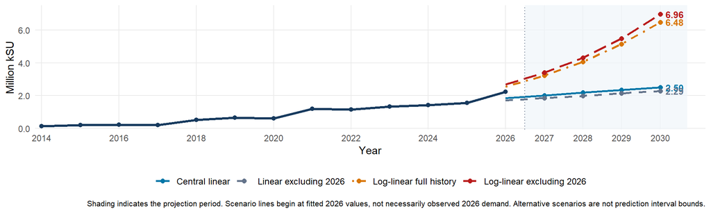

Figure 10: Historical HPC demand and forecast scenarios to 2030.

The central linear model projects HPC demand of approximately 2.02 million kSU in 2027 and 2.50 million kSU in 2030, increasing by 161,992 kSU annually. Excluding 2026 reduces the 2030 projection to 2.29 million kSU, approximately 210,000 kSU below the central estimate.

The full history log-linear model projects 6.48 million kSU in 2030, compared with 6.96 million kSU when 2026 is excluded. These substantially higher projections reflect continued proportional growth. However, the log-linear model had the highest forecast errors in Section 4.2.1 and was retained for sensitivity analysis rather than as a central forecast.

The growth assumption has a greater effect on the 2030 projection than excluding 2026. The central linear forecast provides the main reference for national HPC planning, while the alternatives show how projections change under different assumptions. These estimates represent recorded requests rather than direct measures of future infrastructure capacity requirements.

#### 4.3.1.1 Prediction Intervals and Forecast Uncertainty

The alternative forecasting scenarios show how projections change under different model assumptions. Statistical prediction intervals instead estimate the range of future annual demand under the selected linear model and its error assumptions. Figure 11 shows the central HPC forecast with 80% and 95% prediction intervals.

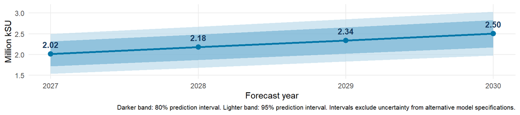

Figure 11: HPC demand forecast with 80% and 95% prediction intervals, 2027-2030

The central model projects 2.50 million kSU in 2030, with a 95% prediction interval of approximately 1.98–3.03 million kSU. This interval describes uncertainty around an individual future annual observation, conditional on the fitted linear model.

The intervals do not account for alternative growth models, changes in computing technology or reporting practices, or demand not captured by recorded requests. The residual diagnostics in Section 4.2.4 also showed departures from the normal-error assumption. These intervals should therefore not be treated as definitive bounds on future national HPC demand.

### 4.3.2 CPU Demand

The linear trend model was fitted to the 2014–2026 CPU demand series to project demand through 2030. Three alternatives were examined: a linear model excluding 2026 and two log-linear models fitted with and without 2026. The linear model was retained as the central forecast based on its slightly lower RMSE in Section 4.2.2. Figure 12 compares the historical CPU demand series with the four projected trajectories.

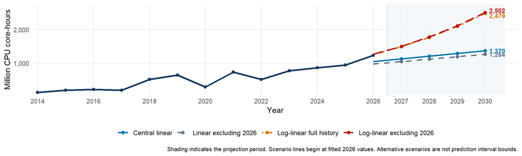

Figure 12: Historical CPU demand and forecast scenarios to 2030.

The central linear model projects approximately 1.13 billion CPU core-hours in 2027, increasing by 81.01 million core-hours annually to reach 1.37 billion in 2030. Excluding 2026 reduces the 2030 projection to approximately 1.26 billion core-hours, around 106 million below the central forecast.

The full-history log-linear model projects 2.48 billion core-hours in 2030, approximately 81% above the central forecast. The log-linear model excluding 2026 produces a similar projection of approximately 2.50 billion core-hours. Despite comparable one-year-ahead accuracy in Section 4.2.2, the linear and log-linear forecasts diverge because they assume constant absolute and proportional growth, respectively.

The linear model remains the central reference because it achieved the lowest RMSE. The log-linear projections are retained as alternative growth scenarios, although the available observations do not establish whether proportional growth will continue through 2030.

#### 4.3.2.1 CPU Prediction Intervals

The alternative CPU forecasts show the effects of model selection and excluding 2026. Prediction intervals instead describe uncertainty around future annual observations under the selected linear model. Figure 13 presents the central CPU forecast with 80% and 95% prediction intervals for 2027 - 2030.

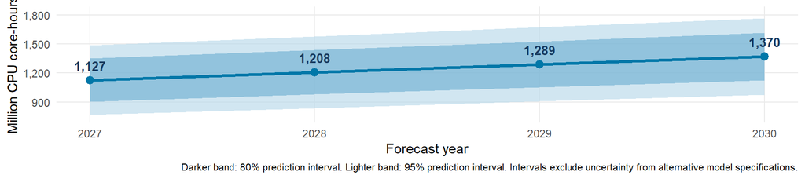

Figure 13: CPU demand forecast with 80% and 95% prediction intervals, 2027-2030.

The central model projects approximately 1.37 billion CPU core-hours in 2030, with a 95% prediction interval of 0.97 - 1.77 billion core-hours. This interval describes uncertainty around an individual annual observation under the fitted linear model.

The full-history log-linear projection of 2.48 billion core-hours lies above this interval because it assumes a different growth pattern. The interval does not capture uncertainty from alternative models, historical resource conversions or changes in computing systems. Departures from normality in the CPU residuals, discussed in Section 4.2.4, also limit confidence in the model-based interval.

CPU projections should be considered alongside overall HPC demand rather than added to it, because the two series represent related computing requirements.

### 4.3.3 GPU Demand

GPU demand projections were treated as exploratory because only five annual observations from 2022–2026 were available for modelling. No central model or statistical prediction intervals were selected, as discussed in Section 4.2.3. Figure 14 compares the historical GPU demand estimates with five projections through 2030.

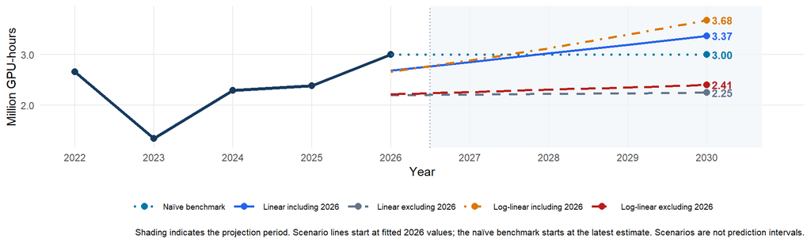

Figure 14: Historical GPU demand and exploratory forecast scenarios to 2030.

The naïve benchmark projects approximately 3.00 million GPU-hours in 2030. The linear and log-linear models fitted through 2026 project 3.37 million and 3.68 million GPU-hours, respectively. Excluding 2026 reduces these projections to 2.25 million and 2.41 million GPU-hours.

The difference between the two linear projections is approximately 1.12 million GPU-hours, with the model including 2026 producing a 49.7% higher estimate. Across all five scenarios, projected demand ranges from 2.25 to 3.68 million GPU-hours. This range reflects alternative assumptions rather than validated prediction bounds.

Given the short historical series and estimated observations, these projections remain exploratory. They were not used to distribute the national HPC forecast across research fields in Section 4.4.

## 4.4 Field of Research Scenarios

Historical Field of Research (FoR) allocation shares were used to distribute the national HPC demand forecast across nine research field groups for 2027 - 2030. Three reference periods were compared: 2014-2020, 2021-2026 and 2014-2026. Because consistent field-level request data were unavailable, these distributions represent allocation-share scenarios rather than independent forecasts of demand by research field.

### 4.4.1 Scenario Construction

For each reference period, the mean annual allocation share of each research-field group was calculated from its available observations and normalised so that the nine groups accounted for 100% of the national forecast:

$$w_f^{(s)} =
\frac{\overline{a}_f^{(s)}}
{\sum_j \overline{a}_j^{(s)}}$$

Here, $w_f^{(s)}$ is the normalised weight for research field $f$ under scenario $s$, and $\overline{a}_f^{(s)}$ is its mean annual allocation share during the reference period.

Each available year received equal weight when calculating a group’s mean allocation share. Missing observations were not treated as zero, so some group weights are based on fewer years than others. Normalising these means ensures that the nine weights sum to 100%, but it does not remove differences in reporting coverage. The weights were held constant for 2027–2030 and represent alternative historical allocation patterns rather than forecasts of future research-field shares.

### 4.4.2 Historical Allocation Assumptions

The three scenarios use different historical allocation compositions. Table 9 reports the normalised weights for all nine research-field groups, together with the number of years used to calculate each weight.

Table 9: Normalised FoR allocation weights and reporting coverage across three historical reference periods.

| Research field | Earlier (2014-2020) | Recent (2021-2026) | Full period (2014-2026) |
| --- | --- | --- | --- |
| Engineering & Technology | 16.24% (7) | 33.28% (6) | 24.19% (13) |
| Physical Sciences | 16.26% (7) | 21.11% (6) | 18.55% (13) |
| Chemical Sciences | 18.28% (7) | 17.02% (6) | 17.74% (13) |
| Earth & Environmental Sciences | 30.38% (7) | 13.36% (6) | 22.55% (13) |
| Unclassified & Operational | 6.98% (5) | 6.75% (2) | 6.92% (7) |
| Biological & Agricultural Sciences | 4.69% (7) | 4.93% (6) | 4.81% (13) |
| Mathematics & Computing | 4.51% (6) | 2.13% (6) | 3.32% (12) |
| Medical & Health Sciences | 2.38% (4) | 1.12% (6) | 1.63% (10) |
| Social Sciences, Humanities & Built Environment | 0.30% (1) | 0.30% (4) | 0.30% (5) |

*Note: Each cell reports the normalised allocation weight and the number of years with observations in parentheses. The three reference periods contain seven, six and thirteen years, respectively.*

Under the earlier-period scenario, Earth and Environmental Sciences has the largest weight (30.38%), followed by Chemical Sciences (18.28%). In the recent-period scenario, Engineering and Technology becomes the largest group (33.28%), while Earth and Environmental Sciences falls to 13.36%. The full-period weights generally lie between the earlier and recent compositions for the major research fields.

Reporting coverage varies across groups. Unclassified and Operational has only two reported years in the recent period, while Social Sciences, Humanities and Built Environment has five across the full period. Changes in FoR classifications and the inclusion of Pawsey-wide reporting in 2016/17 also limit historical comparability.

### 4.4.3 Illustrative Distribution of HPC Demand, 2027 - 2030

The three historical allocation compositions were applied to the central linear HPC demand forecast for each year from 2027 to 2030. The projected demand for field $f$ in year $t$ under scenario $s$ was calculated as $\hat{D}_{f,t}^{(s)} = \hat{D}_t w_f^{(s)}$, where $\hat{D}_t$ is the national HPC demand forecast and $w_f^{(s)}$ is the fixed allocation weight.

Figure 15 shows the resulting annual distributions. Each panel uses the same national demand forecast, but applies a different historical allocation pattern.

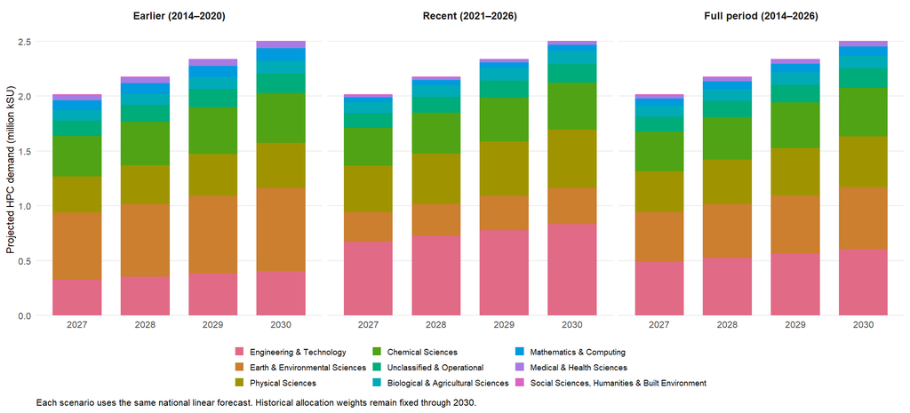

Figure 15: Projected HPC demand by research field under three allocation scenarios, 2027-2030.

Figure 15 shows increasing projected HPC demand across all three scenarios from 2027 to 2030. Engineering and Technology accounts for a larger share under the recent-period scenario, while Earth and Environmental Sciences has a larger share under the earlier period scenario. Because the allocation weights remain fixed, the scenarios differ in their research-field distributions rather than their national demand totals or growth rates.

### 4.4.4 Comparison of Projected Demand in 2030

The 2030 endpoint provides a direct comparison of the three allocation assumptions. Table 10 reports the projected demand for each research-field group, calculated using the unrounded national forecast.

Table 10: Illustrative 2030 HPC demand distribution under three historical FoR allocation scenarios, in kSU.

| Research field | Earlier (2014-2020) | Recent (2021-2026) | Full period (2014-2026) |
| --- | --- | --- | --- |
| Engineering & Technology | 406,401 | 832,908 | 605,405 |
| Physical Sciences | 406,985 | 528,466 | 464,339 |
| Chemical Sciences | 457,455 | 425,998 | 443,903 |
| Earth & Environmental Sciences | 760,374 | 334,353 | 564,291 |
| Unclassified & Operational | 174,599 | 168,853 | 173,130 |
| Biological & Agricultural Sciences | 117,258 | 123,418 | 120,389 |
| Mathematics & Computing | 112,832 | 53,320 | 83,184 |
| Medical & Health Sciences | 59,462 | 28,081 | 40,714 |
| Social Sciences, Humanities & Built Environment | 7,455 | 7,426 | 7,467 |

The central linear model projects approximately 2.50 million kSU of national HPC demand in 2030. Under the recent-period scenario, Engineering and Technology accounts for 832,908 kSU, compared with 406,401 kSU under the earlier-period scenario, a difference of 426,507 kSU.

Earth and Environmental Sciences shows the opposite pattern, with 760,374 kSU under the earlier-period scenario and 334,353 kSU under the recent-period scenario. The full-period scenario produces intermediate values for both groups.

These differences arise from the historical allocation weights rather than changes in the national forecast. The results illustrate how assumptions about research-field composition affect indicative demand distribution, but they are not confirmed future allocations or independently validated field-level demand forecasts. Chapter 5 discusses their planning implications.

## 4.5 HPC Allocation Sensitivity Scenarios

The central HPC forecast was used to examine how different allocation levels would affect the request–allocation gap in 2030. Three illustrative scenarios were considered: allocations remaining at the 2026 level, increasing by 25%, or increasing by 50%. These assumptions represent changes in recorded allocations relative to 2026, not independently forecast infrastructure capacity.

For each scenario, the projected gap was calculated as forecast requests minus assumed allocations, while fulfilment was calculated as assumed allocations divided by forecast requests. The analysis uses the central HPC forecast from Section 4.3.1 and the 2026 allocation baseline reported in Section 4.1.1.

Table 11: Illustrative 2030 HPC allocation scenarios relative to the 2026 allocation baseline.

| Scenario | Allocation (million kSU) | Gap (million kSU) | Fulfilment (%) |
| --- | --- | --- | --- |
| 2026 allocation level | 0.87 | 1.63 | 34.9 |
| 25% increase | 1.09 | 1.41 | 43.6 |
| 50% increase | 1.31 | 1.19 | 52.3 |

Table 11 shows that maintaining allocations at the 2026 level would leave approximately 1.63 million kSU of projected requests unmet in 2030, with a fulfilment rate of 34.9%. A 50% increase in allocations would reduce the gap to 1.19 million kSU and raise fulfilment to 52.3%.

To maintain the 2026 fulfilment rate of 38.9%, allocations would need to reach approximately 0.97 million kSU in 2030, an increase of 11.6% from the 2026 level. Achieving 50% fulfilment would require approximately 1.25 million kSU, or 43.5% above 2026 allocations. These comparisons show how different allocation targets affect the scale of unmet requests under the central demand forecast.

The scenarios are illustrative rather than forecasts of future capacity. Differences in service-unit accounting, computing technology, allocation policies and researcher behaviour could affect future requests and allocations. The results therefore indicate the scale of recorded allocations needed under each assumption, not the physical infrastructure or investment required.

# 5 Discussion

## 5.1 Interpretation of the Main Findings

### 5.1.1 Growing Difference Between Demand and Allocation

The historical analysis shows that requested HPC resources grew faster than allocations. In 2026, recorded requests reached approximately 2.24 million kSU, while allocations were approximately 872,000 kSU, giving a fulfilment rate of 38.9%. The difference indicates that the allocation scheme could not meet all recorded requests.

However, the request–allocation gap does not measure total unmet national demand. Researchers may limit their requests according to expected availability, while others may not apply. The records also do not establish whether all requested resources would have been used if awarded. The gap therefore measures the difference within the reported allocation process, not the additional computing capacity Australia would need to satisfy all potential research activity.

### 5.1.2 Interpretation of the Forecasting Results

The rolling-origin evaluation favoured the linear trend for overall HPC demand. It produced lower forecast errors than the alternative methods, particularly the log-linear model. This supports using a constant annual increase as the central forecasting assumption, although the six evaluation years provide limited evidence about performance through 2030.

The CPU results were less decisive. Linear achieved the lowest RMSE, while log-linear achieved the lowest MAE. Their similar one-year-ahead accuracy means that the choice between constant absolute growth and proportional growth has a greater effect on the longer-term CPU projection than the evaluation results alone can resolve.

For overall HPC demand, excluding 2026 reduced the 2030 linear projection from 2.50 million to 2.29 million kSU. The full history log-linear model projected 6.48 million kSU, despite its weaker evaluation performance. For CPU demand, the full history log-linear projection reached approximately 2.48 billion core-hours, compared with 1.37 billion under the selected linear model. These differences show how the assumed growth pattern affects projections beyond the one year evaluation horizon.

The statistical prediction intervals and alternative model scenarios represent different sources of uncertainty. The intervals are conditional on the selected linear models and their error assumptions. The alternative scenarios show the effects of changing the historical sample or growth specification. Neither accounts fully for uncertainty in historical conversions, future computing technology or research policy.

### 5.1.3 GPU and Field of Research Findings

GPU demand could not be forecast with the same level of confidence as overall HPC or CPU demand. The five-year modelling series produced only two one-year-ahead evaluation errors per model. Although the naïve benchmark had the lowest errors, this was insufficient to establish a reliable forecasting method through 2030. The GPU projections were therefore retained as exploratory results rather than estimates of future capacity requirements.

The Field of Research (FoR) scenarios identified a separate issue. Applying earlier and recent allocation shares to the same national HPC forecast produced substantially different distributions across research fields. For Engineering and Technology, the difference between the two 2030 scenarios was approximately 426,500 kSU. Earth and Environmental Sciences received a larger indicative share under the earlier-period scenario.

These differences reflect the historical allocation periods used to construct the scenarios. They cannot establish equivalent changes in underlying research demand because the data include classification changes, reporting differences and capacity constrained allocations.

## 5.2 Implications for National HPC Planning

### 5.2.1 Planning for Growth and Uncertainty

The central HPC forecast provides a reference for national planning, but the alternative projections show how strongly the 2030 estimate depends on the assumed growth pattern. Planning should therefore consider the central forecast alongside the sensitivity scenarios rather than relying on a single demand estimate.

The allocation sensitivity analysis in Section 4.5 provides a further comparison. If allocations remained at the 2026 level, approximately 1.63 million kSU of projected requests would remain unmet in 2030, with fulfilment of 34.9%. Even a 50% increase in allocations would leave a gap of approximately 1.19 million kSU, with a fulfilment rate of 52.3%. Maintaining the 2026 fulfilment rate of 38.9% would require allocations to increase by approximately 11.6% under the central forecast.

These results provide indicative allocation levels for planning discussions, not estimates of infrastructure capacity or investment requirements. Translating them into capacity decisions would require evidence on resource utilisation, workload characteristics, system performance and future allocation policies.

### 5.2.2 Accounting for Changes in Computing Technology

HPC, CPU and GPU demand are expressed in different units and should not be added together. Changes in hardware performance and service-unit accounting also affect comparisons between historical demand and future computing capacity.

For example, a newer CPU system may complete the same workload using fewer core-hours, while different GPU architectures may require different processing times for comparable tasks. Consequently, growth in reported computing demand does not necessarily imply an equivalent increase in physical infrastructure requirements.

Capacity assessments should therefore combine the demand projections with information on system performance, resource utilisation, workload requirements and planned hardware changes.

### 5.2.3 Considering Research Field Requirements

The FoR scenarios show how the assumed distribution of national HPC demand changes when different historical allocation periods are used. The recent period scenario places greater weight on Engineering and Technology, while the earlier-period scenario places greater weight on Earth and Environmental Sciences.

These distributions should not be used as fixed allocation targets. Historical shares reflect allocation decisions as well as research activity, and the available data do not establish future demand within individual fields. More consistent FoR level request and usage records would be needed before developing field-specific capacity estimates.

## 5.3 Limitations and Future Work

### 5.3.1 Study Limitations

The overall HPC and CPU models were fitted using 13 annual observations from 2014-2026. Their evaluation covered six one year ahead forecasts, which provides limited evidence about accuracy over the four year projection horizon. The GPU series was shorter, with five modelling observations and only two evaluation years.

A major challenge was integrating historical records from NCI, Pawsey and NCMAS. The sources differed in reporting periods, computing systems, resource definitions, units and levels of detail. Some years provided directly reported demand and allocation figures, while others required reconstruction or conversion. As a result, producing a consistent national dataset required assumptions about how observations from different sources could be combined. These differences limit comparability across years and introduce uncertainty before forecasting begins.

The selected linear models also assume that historical absolute growth continues through 2030. They do not explicitly account for future changes in research funding, technology, allocation policies or facility capacity. The sensitivity analysis showed that including the 2026 observation materially affected the fitted trends and projections.

The FoR scenarios were based on historical allocation shares rather than independently observed demand within each field. Differences between FoR 2008 and FoR 2020 classifications, together with changes in reporting scope, limit the comparability of these shares. Normalising them to 100% does not remove those differences.

The allocation sensitivity scenarios also assume that the 2026 allocation baseline is comparable with the projected 2030 demand measure. They do not model changes in allocation policy, researcher application behaviour or available computing capacity. Their results are therefore conditional comparisons rather than forecasts of future unmet demand.

### 5.3.2 Recommendations for Future Work

Further analysis should prioritise the following improvements:

1. **Standardise and integrate national HPC reporting.** Establish consistent annual reporting across NCI, Pawsey and NCMAS, including requested, allocated and used resources, reporting periods, computing systems and measurement units. Common definitions and documented conversion factors would reduce the need to reconstruct historical observations and improve the reliability of future demand forecasts.
2. **Validate resource conversion factors.** Consultation with facility operators could help confirm historical accounting factors, particularly where computing systems or resource definitions changed.
3. **Extend the GPU demand series.** More detailed GPU request, allocation and usage records would allow forecasting methods to be evaluated over a longer period and reduce reliance on estimated observations.
4. **Improve FoR-level demand information.** Consistent research-field request records and validated classification mappings would support direct field-level forecasting instead of distributing national projections using historical allocation shares.
5. **Update and evaluate forecasts annually.** Re-estimating the models as new observations become available would allow forecast errors, growth assumptions and sensitivity to recent years to be reassessed.
6. **Connect demand projections with infrastructure characteristics.** Information on hardware performance, utilisation, workload requirements and expected system changes would help translate projected demand into practical capacity assessments.

# 6 Conclusion

This project examined Australian national research HPC demand from 2014 to 2026 and developed projections through 2030 using publicly available NCI, Pawsey and NCMAS records. A major challenge was integrating historical data reported under different computing systems, measurement units and reporting practices. The analysis documented the conversions and assumptions required to construct comparable annual series.

Recorded HPC requests reached approximately 2.24 million kSU in 2026, compared with allocations of 872,288 kSU, giving a fulfilment rate of 38.9%. The difference indicates that recorded requests substantially exceeded allocations, although it does not measure all unmet research demand.

Rolling-origin evaluation supported linear trend models for the central HPC and CPU projections. By 2030, these models project approximately 2.50 million kSU of HPC demand and 1.37 billion CPU core-hours. The projections remain sensitive to the inclusion of 2026 and the assumed growth pattern. GPU projections were retained as exploratory because only five annual modelling observations were available. The FoR scenarios showed how different historical allocation distributions affect the estimated composition of future demand.

The allocation sensitivity analysis further showed that a 50% increase from the 2026 allocation level would fulfil only approximately 52% of projected HPC requests in 2030, under the central demand forecast.

The project delivers documented historical datasets, evaluated forecasting models and demand scenarios through 2030. These provide the Australian Academy of Science with a reference for national HPC planning and a basis for updating the analysis as new data become available. However, the findings also show that demand projections need to be considered alongside allocation constraints, computing system performance and changes in resource accounting before they can inform future capacity decisions. The accompanying Quarto documentation and Git repository retain the preparation steps, assumptions and code needed to review and update the results.

# 7 References

Australian Academy of Science. 2024. “The Future Computing Needs of the Australian Science Sector.” https://www.science.org.au/.

Australian Academy of Science. 2026. *Internship Project Brief: Forecasting Demand for National Research Supercomputing*.

Australian Bureau of Statistics. 2020. “Australian and New Zealand Standard Research Classification (ANZSRC), 2020.” https://www.abs.gov.au/statistics/classifications/australian-and-new-zealand-standard-research-classification-anzsrc/2020.

Hyndman, Rob J., and George Athanasopoulos. 2021. *Forecasting: Principles and Practice*. 3rd ed. OTexts. https://otexts.com/fpp3/.

Hyndman, Rob J., and Anne B. Koehler. 2006. “Another Look at Measures of Forecast Accuracy.” *International Journal of Forecasting* 22 (4): 679–88. https://doi.org/10.1016/j.ijforecast.2006.03.001.

National Computational Infrastructure. 2014a. *Annual Report 2013/14*. https://nci.org.au/sites/default/files/annual-reports/2019-07/About%20Us_Annual%20Reports_2013-14.pdf.

National Computational Infrastructure. 2014b. “NCMAS Information for Applicants.” https://nci.org.au/news-events/news/ncmas-information-applicants.

National Computational Infrastructure. 2015. *Annual Report 2014/15*. https://nci.org.au/sites/default/files/annual-reports/2019-07/About%20Us_Annual%20Reports_2014-15.pdf.

National Computational Infrastructure. 2016. *Annual Report 2015/16*. https://nci.org.au/sites/default/files/annual-reports/2019-07/About%20Us_Annual%20Reports_2015-16.pdf.

National Computational Infrastructure. 2017. *Annual Report 2016/17*. https://nci.org.au/sites/default/files/annual-reports/2019-07/About%20Us_Annual%20Reports_2016-17.pdf.

National Computational Infrastructure. 2018. *Annual Report 2017/18*. https://nci.org.au/sites/default/files/annual-reports/2019-07/About%20Us_Annual%20Reports_2017-18.pdf.

National Computational Infrastructure. 2019. *Annual Report 2018/19*. https://nci.org.au/sites/default/files/annual-reports/2019-11/NCI%20Report%202019%20web.pdf.

National Computational Infrastructure. 2020a. *Annual Report 2019/20*. https://nci.org.au/sites/default/files/annual-reports/2021-01/NCI%20Annual%20report%202019-20%20web_final_opt2.pdf.

National Computational Infrastructure. 2020b. *NCMAS 2020 Information for Applicants*. https://nci.org.au/sites/default/files/documents/2019-10/NCMAS-2020-InformationForApplicants.pdf.

National Computational Infrastructure. 2022. *NCMAS 2023 Information for Applicants*. https://my.nci.org.au/mancini-assets/media/mas/ncmas/2023/NCMAS2023-NCMAS_2023_Info4Applicants_v5-20220830T164026AEST.pdf.

National Computational Infrastructure. 2023. *NCMAS 2024 Information for Applicants*. https://my.nci.org.au/mancini-assets/media/mas/ncmas/2024/NCMAS2024-NCMAS_2024_-_Information_for_Applicants_20231109-20231109T131740AEDT.pdf.

National Computational Infrastructure. 2025. *NCMAS 2026 Information for Applicants*. https://my.nci.org.au/mancini-assets/media/mas/ncmas/2026/NCMAS2026-Information_for_Applicants-20251023T122535AEDT.pdf.

National Computational Infrastructure. n.d.-a. *HPC Systems*. Accessed October 18, 2026. https://nci.org.au/infrastructure/hpc-systems.

National Computational Infrastructure. n.d.-b. “Who We Are.” Accessed October 4, 2026. https://nci.org.au/.

National Computational Merit Allocation Scheme. 2021. “NCMAS 2021 Outcomes.” https://my.nci.org.au/mancini/ncmas/2021/outcomes.

National Computational Merit Allocation Scheme. 2022. “NCMAS 2022 Outcomes.” https://my.nci.org.au/mancini/ncmas/2022/outcomes.

National Computational Merit Allocation Scheme. 2023. “NCMAS 2023 Outcomes.” https://my.nci.org.au/mancini/ncmas/2023/outcomes.

National Computational Merit Allocation Scheme. 2024. “NCMAS 2024 Outcomes.” https://my.nci.org.au/mancini/ncmas/2024/outcomes.

National Computational Merit Allocation Scheme. 2025. “NCMAS 2025 Outcomes.” https://my.nci.org.au/mancini/ncmas/2025/outcomes.

National Computational Merit Allocation Scheme. 2026. “NCMAS 2026 Outcomes.” https://my.nci.org.au/mancini/ncmas/2026/outcomes.

Pawsey Supercomputing Research Centre. 2017. *Annual Report 2016/17*. https://pawsey.org.au/wp-content/uploads/2018/10/Pawsey-Annual-Report-2016-2017.pdf.

Pawsey Supercomputing Research Centre. n.d.-a. “About Pawsey.” Accessed October 4, 2026. https://pawsey.org.au/.

Pawsey Supercomputing Research Centre. n.d.-b. *Changes in Supercomputing Services for 2023*. Accessed October 18, 2026. https://pawsey.atlassian.net/wiki/spaces/US/pages/51927586/Changes+in+Supercomputing+Services+for+2023.

Pawsey Supercomputing Research Centre. n.d.-c. *Setonix Fires up for Researchers*. Accessed October 18, 2026. https://pawsey.org.au/setonix-fires-up-for-researchers/.

Tashman, Leonard J. 2000. “Out-of-Sample Tests of Forecasting Accuracy: An Analysis and Review.” *International Journal of Forecasting* 16 (4): 437–50. https://doi.org/10.1016/S0169-2070(00)00065-0.